# Data curation: Tidy data & metadata

Simon Podhajsky & David Condon

July 30, 2017

## Outline

The steps needed to get a shareable dataset!

1. Getting your data set tidied up
2. Creating metadata documentation

# Part 1: Tidy data

## Slogan

> Write code for humans. Write data for computers.

> – Vince Buffalo, [Bioinformatics Data Skills](http://shop.oreilly.com/product/0636920030157.do)

## First: What challenges do *you* face?

## Note on file organization

```
 data/raw/
 data/clean/
 processing/
 analysis/
 README
```

We will be sharing two files *at minimum*

## Note on file formats

Preferred:

- plain text
- open (non-proprietary) format
  - I don’t need to buy software to view this
  - Ideally, I don’t need to *install* software to view this

## Data is tidy if…

1. each observation occupies a single row
2. each variable occupies a single column
3. one type of observations resides in a single table.

## Data is tidy if…

1. each observation occupies a single row
2. each variable occupies a single column
3. one type of observations resides in a single table.

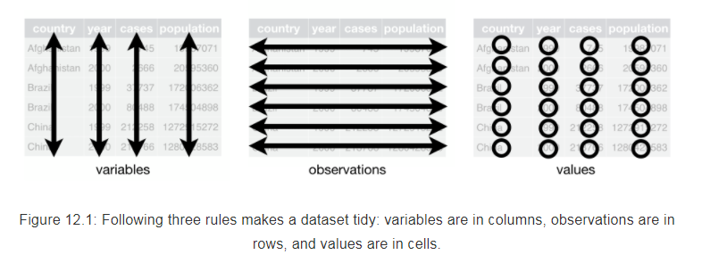

(source: [Chapter 12 of *R for Data Science*](http://r4ds.had.co.nz/tidy-data.html#fig:tidy-structure))

## Yeah, right

> - Is observation…
>   - a survey submission?
>   - each response in that submission?
> - What separates kinds of observation?
> - What separates observations from variables? (`work_phone` vs. `home_phone`)
> - Might depend on context and discretion, but broad intuitions apply broadly

## Negative take: tidy ~ not messy

Messy data is usually messy in the following ways:

> - Column headers are values, not variable names
> - Multiple variables are stored in one column
> - Variables are stored in both rows and columns
> - Multiple types of experimental unit stored in the same table
> - One type of experimental unit stored in multiple tables

We’ll go over each in the example.

## Origin of “tidy data”

[Hadley Wickham’s (2014) Tidy Data paper.](https://www.jstatsoft.org/article/view/v059i10) Do read it if you can.

(much of this presentation is modeled on [his original slides](http://stat405.had.co.nz/lectures/18-tidy-data.pdf))

# Messy dataset example: Your plans for SIPS

- Remember that form you filled out? We’ll look at the CSV output from Google Forms.
- (Examples are a little `R` heavy, but many tools do the same)
- Only code excerpts shown; for full code, [check out the RMarkdown source of this presentation.](https://github.com/shippy/sips-curating-data-2017/blob/master/tidying_sips_plans.Rmd)

## Dataset excerpt (1/2)

```r
knitr::kable(x[106, 1:4], row.names = FALSE)
```

| Timestamp | Name | Email address | Which events do you plan to attend on Sunday, July 30? |
| --- | --- | --- | --- |
| 7/17/2017 10:45:31 | Fred Satterfield | px@kiwabmx.bzq | [Saturday, July 29th, 7p] Dinner/drinks party at Brian Nosek's home (bus transportation to/from Omni hotel all evening), Workshop: Fundamentals of meta-analysis (9:30a-12:30p), Workshop: Using OSF (1:… |

## Dataset excerpt (2/2)

| Which events do you plan to attend on Monday, July 31? (not including lightning talks, unconference sessions, and hackathons that will continue or start on 2nd day) | Which events do you plan to attend on Tuesday, August 1st? |
| --- | --- |
| Workshop: R Markdown (1:30-3:30p), Workshop: Power analysis and effect size (3:30p-5:30p), All Conference Social Event (Dinner+drinks; 7:30p-??) | Workshop: Fundamentals of R (9:30a-12:30p) |

## What are the problems here?

> - Unwieldy column names
> - Ambiguous commas - some separate plans, others are used in a sentence
>   - “Workshop: Using OSF (1:30-3:30p), Workshop: Writing papers to be transparent, reproducible, and fabulous (3:30-5:30p)”
> - Identifying personal information
> - Data mistakes?
>   - Brian’s social event is listed on the wrong day
>   - What timezone is the datetime? *(More in the *Metadata* section)*
>   - Double submissions?
> - And, of course, not tidy

```r
# Read the file in with better headers
library(readr)
x <- read_csv('data/raw/plans_raw.csv',
              col_names = c("time_submitted", "name", "email",
                            "day1", "day2", "day3"),
              col_types = list(
                col_datetime(format = '%m/%d/%Y %H:%M:%S'),
                col_character(), col_character(),
                col_character(), col_character(),
                col_character()),
              skip = 1) # skip row with headers
head(x)
```

| time_submitted | name | email | day1 | day2 | day3 |
| --- | --- | --- | --- | --- | --- |
| 2017-07-14 11:54:46 | Bernadine Ratke | ad@xosz.tdi | Workshop: Data Sharing -- Part 1: IRB, Part 2: Curating data (3:30-6p), Hack: Forming a new journal (all day), Hack: Action campaign for all psych journals to adopt transparency policies (all day) | All Conference Social Event (Dinner+drinks; 7:30p-??) | Everything else will be scheduled during the conference depending on what has legs and group interest |
| 2017-07-14 10:13:10 | Juliane Kling | jbacqmnoug@qcsrv.hut | [Saturday, July 29th, 7p] Dinner/drinks party at Brian Nosek's home (bus transportation to/from Omni hotel all evening), Workshop: Using OSF (1:30-3:30p), Hack: Syllabus for Research Methods (all day)… | All Conference Social Event (Dinner+drinks; 7:30p-??) | Everything else will be scheduled during the conference depending on what has legs and group interest |
| 2017-07-14 10:14:02 | Argelia DuBuque | sbinxjw@bprhc.ybo | [Saturday, July 29th, 7p] Dinner/drinks party at Brian Nosek's home (bus transportation to/from Omni hotel all evening), Hack: Syllabus for Research Methods (all day), I am flexible; if there is a hac… | All Conference Social Event (Dinner+drinks; 7:30p-??) | Everything else will be scheduled during the conference depending on what has legs and group interest |
| 2017-07-14 10:16:39 | Williams Mueller | xrugcmajh@qbaetkvwmj.kwe | [Saturday, July 29th, 7p] Dinner/drinks party at Brian Nosek's home (bus transportation to/from Omni hotel all evening), Workshop: Fundamentals of meta-analysis (9:30a-12:30p), Workshop: Writing paper… | All Conference Social Event (Dinner+drinks; 7:30p-??) | Everything else will be scheduled during the conference depending on what has legs and group interest |
| 2017-07-14 11:17:02 | Davida Ledner | iokv@vl.dyt | Workshop: How to Promote Transparency and Replicability as a Reviewer (1:30-3:30p), Workshop: Writing papers to be transparent, reproducible, and fabulous (3:30-5:30p) | All Conference Social Event (Dinner+drinks; 7:30p-??) | Everything else will be scheduled during the conference depending on what has legs and group interest |
| 2017-07-16 03:07:14 | Ethan Klocko | kl@jbn.vmb | [Saturday, July 29th, 7p] Dinner/drinks party at Brian Nosek's home (bus transportation to/from Omni hotel all evening), Hack: Syllabus for Research Methods (all day) | All Conference Social Event (Dinner+drinks; 7:30p-??) | Everything else will be scheduled during the conference depending on what has legs and group interest |

```r
knitr::kable(x[106, 4:6], row.names = FALSE)
```

| day1 | day2 | day3 |
| --- | --- | --- |
| [Saturday, July 29th, 7p] Dinner/drinks party at Brian Nosek's home (bus transportation to/from Omni hotel all evening), Workshop: Fundamentals of meta-analysis (9:30a-12:30p), Workshop: Using OSF (1:… | Workshop: R Markdown (1:30-3:30p), Workshop: Power analysis and effect size (3:30p-5:30p), All Conference Social Event (Dinner+drinks; 7:30p-??) | Workshop: Fundamentals of R (9:30a-12:30p) |

Now, let’s talk about what makes this messy.

## Mess #1: mixing different data sets

> - Our datasets centers on plans for specific events. Why should we have people’s emails here?
> - If we need to do any processing on a per-person level, things become unwieldy fast.

[figure not shown]

**Tidy solution:** divide the data units into tables you can merge as needed

```r
people <- select(x, time_submitted, name, email) %>% unique()
people$data_origin <- 'plans_raw.csv' # if many possible sources
# if non-existent, create an ID to join the tables by.
# (Usually, you might have an ID for each participant at
# this point, which you'd now deidentify.)
people$participant_ID = sample(1:nrow(people), nrow(people))
# remove the people-specific data from `x`
x <- merge(x, people) %>% select(-time_submitted, -name,
                                 -email, -data_origin)
```

> - **Question:** Should we separate the table of events and plans, too?

As a bonus, sensitive info is relegated to a single spot, and is easier to deal with - for example, extract non-identifying features of interest:

```r
# dplyr::transmute drops all columns that are not explicitly named
people <- transmute(people,
                    time_submitted, participant_ID,
                    email_server = gsub('.+@([^@]+)$', '\\1', email),
                    number_names = length(strsplit(name, ' ')[[1]])
)
```

| time_submitted | participant_ID | email_server | number_names |
| --- | --- | --- | --- |
| 2017-07-14 11:54:46 | 30 | xosz.tdi | 2 |

Of course, this might still be identifying information - consult your local HIPAA board.

## Mess #2: Data stored in column names

| day1 | day2 | day3 | participant_ID |
| --- | --- | --- | --- |
| [Saturday, July 29th, 7p] Dinner/drinks party at Brian Nosek's home (bus transportation to/from Omni hotel all evening), Hack: Syllabus for Research Methods (all day) | Workshop: R Markdown (1:30-3:30p), Re-hack: Diversity and inclusion (morning), All Conference Social Event (Dinner+drinks; 7:30p-??) | NA | 140 |

**Tidy solution:** translate the data from wide to long

```r
x <- tidyr::gather(x, event_day, event, -participant_ID)
x$event_day <- as.numeric(gsub('day', '', x$event_day)) # clean up
```

| participant_ID | event_day | event |
| --- | --- | --- |
| 140 | 1 | [Saturday, July 29th, 7p] Dinner/drinks party at Brian Nosek's home (bus transportation to/from Omni hotel all evening), Hack: Syllabus for Research Methods (all day) |
| 16 | 1 | Workshop: Fundamentals of meta-analysis (9:30a-12:30p), Workshop: Using OSF (1:30-3:30p), Workshop: Writing papers to be transparent, reproducible, and fabulous (3:30-5:30p) |

- *Side effect to note for later: some people are now planning for `NA`. Why?*

## Mess #3: Multiple records in a single row

> - As many plans as there were checkboxes
> - Doing any analysis of event attendance is hard

**Tidy solution:** One row per one intention to attend an event

```r
# not shown: function that escapes non-separator commas
x$event <- escape_multiple_values(x$event)
x <- separate_rows(x, event, sep = ', ')
# unescape the event titles
x$event <- unescape_multiple_values(x$event)
```

We can now easily fix the mis-dating of Brian’s social event, which - as an artifact of survey design - would otherwise still be considered a Day 1 event:

```r
# With just one mis-dated event, we can just re-date it
x$event_day[x$event == paste0("[Saturday, July 29th, 7p] ",
  "Dinner/drinks party at Brian Nosek's home (bus ",
  "transportation to/from Omni hotel all evening)")] <- 0
```

## Mess #4: Multiple variables in a single column

| participant_ID | event_day | event |
| --- | --- | --- |
| 119 | 1 | Workshop: Fundamentals of meta-analysis (9:30a-12:30p) |

What’s wrong here?

> - All mashed up in `event`: event time, event name, **and** event type

```r
# Structure of `event` is stable (Type: name (time)), so
# a regular expression can extract it
#
# (Not shown: slight data manipulation to make this work
#  for all events)
x <- extract(x, event,
             c('event_type', 'event_name', 'event_time'),
             regex = "(^[[:alnum:]-]+): (.+) \\((.+)\\)$",
             remove = FALSE)
```

| participant_ID | event_day | event | event_type | event_name | event_time |
| --- | --- | --- | --- | --- | --- |
| 119 | 1 | Workshop: Fundamentals of meta-analysis (9:30a-12:30p) | Workshop | Fundamentals of meta-analysis | 9:30a-12:30p |

## Mess #5: Multiple types of experimental unit in the same table

> - “I’m flexible” isn’t a plan for a specific event.
> - **Question**: Should such responses be removed or re-defined? When should curation remove responses?
>   - *Relevant: What does a plan for `NA` event mean?*

| participant_ID | event_day | event | event_type | event_name | event_time |
| --- | --- | --- | --- | --- | --- |
| 37 | 1 | I am flexible; if there is a hackathon that needs help, let me know. | NA | NA | NA |

```r
flexible_responses <- c("Everything else will be scheduled during the conference depending on what has legs and group interest",
                        "I am flexible; if there is a hackathon that needs help, let me know.")
# Removal:
# x <- filter(x, !(event %in% flexible_responses))
# Re-definition
x$event_type[x$event %in% flexible_responses] <- "Flexible"
```

| participant_ID | event_day | event | event_type | event_name | event_time |
| --- | --- | --- | --- | --- | --- |
| 37 | 1 | I am flexible; if there is a hackathon that needs help, let me know. | Flexible | NA | NA |

## Mess #6: One type of experimental unit stored in multiple tables

> - Bullet we dodged, but can you imagine examples?
> - If the Plans GForm asked for participant dietary restrictions, and the Lightning Talk GForm asked for participant age, both should be extracted into logical places

## Could we make things even cleaner?

> - Add `event_date`
> - Convert `event_time` to `event_starttime` and `event_duration`
> - Remove `event`, as we’ve extracted everything out of it
> - In fact, separate out `events.csv` into its own table and join by `event_id`

## Real artists ship publish

```r
x <- select(x, -event)
write_csv(x, 'data/clean/event_plans.csv')
write_csv(people, 'data/clean/people.csv')
save(people, x, file = 'data/clean/all_data.Rdata')
```

| participant_ID | event_day | event_type | event_name | event_time |
| --- | --- | --- | --- | --- |
| 119 | 1 | Workshop | Fundamentals of meta-analysis | 9:30a-12:30p |

# Things are easier with a tidy data set

## Tidy data are like a toothpaste

> - A tidy dataset is easy to push into “messy” forms, but backwards doesn’t work quite as well.

## Quick exploration is easy

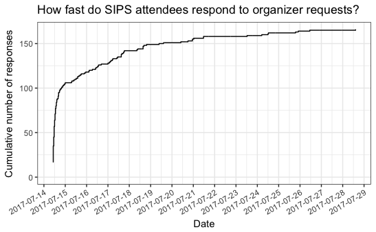

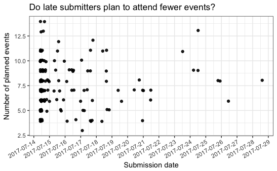

# Tidy tools

## It’s not just R

- [OpenRefine](https://openrefine.org) (formerly Google Refine)
- [Trifacta Wrangler](https://www.trifacta.com/products/wrangler/) (formerly [Data Wrangler](http://vis.stanford.edu/wrangler/))
- Excel “Table” + pivot table shenanigans?
- All statistical software has some version of reshaping tools

…but if you’re looking for R, [`tidyverse`](http://tidyverse.org/) is excellent

# Part 2: Metadata

- How the data was collected & why — study- and table-level documentation
- Follows naturally from a clean dataset
- Allows for usability and findability

## Always be documenting

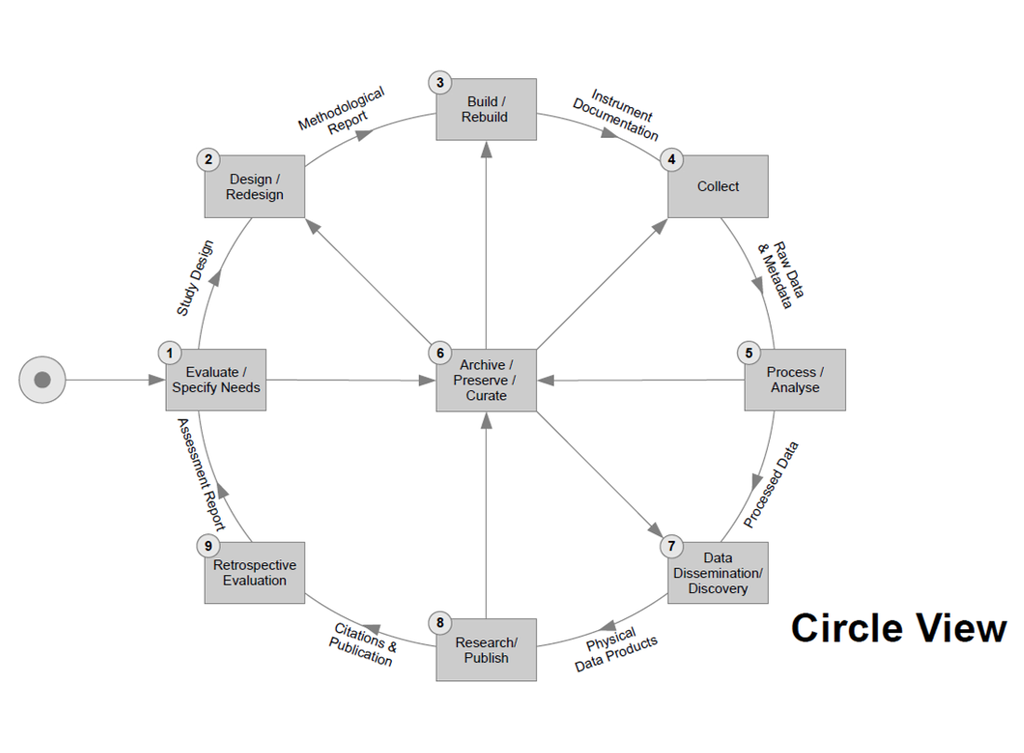

(source: [Wendy Thomas and Marcel Hebing 2013 presentation on DDI](http://www.ddialliance.org/system/files/Thomas-Hebing-2013-EDDI.pptx))

# Option 1: Standardized metadata

## Standardized metadata

- There are many standards, and they have a plan
- Most common in social science: [DDI (Documenting Data Initiative)](http://www.ddialliance.org/)
  - Lifecycle standard
  - Slimmed-down Codebook standard
  - [Examples on the DDI website](http://www.ddialliance.org/resources/markup-examples)
- Alternative standards exist: [Dublin Core](http://dublincore.org/), [MINSEQE](http://fged.org/projects/minseqe/) (genomics), [MIBBI](https://biosharing.org/standards/?selected_facets=isMIBBI:true&view=table) (biology + biomedicine), …

## Pros

> - Very, **very** thoroughly standardized & documented
> - XML means machine-readability
> - Connects into other existing frameworks
> - Ideal for extensive datasets

## Cons

- Far too thoroughly standardized - steep learning curve
- XML does not mean human readability
- Overkill for small-ish datasets

## Tools

- [Colectica software](http://www.colectica.com), especially the free [Colectica for Excel](http://www.colectica.com/software/colecticaforexcel) (Windows-only)
- [Archivist](https://github.com/CLOSER-Cohorts/archivist) by UK’s CLOSER
- [Nesstar](http://www.nesstar.com/software/publisher.html)
- […and DDI has a comprehensive list of others](https://www.ddialliance.org/resources/tools)

# Option 2: “Readme” metadata

## “Readme” metadata

- Flexible description in plain text
- Many templates available - [Cornell Library has an excellent one](https://cornell.app.box.com/v/ReadmeTemplate)

# Documenting our SIPS dataset

## Basics (cont’d)

4. Geographic location of data collection (where was data collected?): **online**
5. Information about funding sources that supported the collection of the data: **COS/SIPS and its funders**

## Sharing / access information

1. Licenses/restrictions placed on the data: **MIT**
2. Links to publications that cite or use the data: -
3. Links to other publicly accessible locations of the data: -
4. Links/relationships to ancillary data sets: **SIPS 2017 registrations**
5. Was data derived from another source? -
6. Recommended citation for the data: *We’ll soon have one!*

## Data and file overview (cont’d)

4. Are there multiple versions of the dataset? **no**
   - If yes, list versions: -
   - Name of file that was updated: -
     1. Why was the file updated? -
     2. When was the file updated? -

*Question: is this necessary if you use version control?*

## Methodological information

1. Description of methods used for collection/generation of data (include references): **Google Form sent to registered participants via e-mail**
2. Methods for processing the data: **Export to CSV, then run `tidying_sips_plans.Rmd`**
3. Instrument- or software-specific information needed to interpret the data: **none, but R 3.4+ preferred**
4. Standards and calibration information, if appropriate: **-**

## Methodological information (cont’d)

5. Environmental/experimental conditions: **-**
6. Describe any quality-assurance procedures performed on the data: **-**
7. People involved with sample collection, processing, analysis and/or submission: **Katie & Brian & … (collection), Simon (processing & analysis), David (submission)**

## `event_plans.csv`

1. Number of variables: **5**
2. Number of cases/rows: **1260**
3. Variable List
   1. Name: **`participant_ID`**
      - Description: **unique participant index linked to the person data in `people.csv`**
   2. Name: **`event_type`**
      - Description: **The format of the event the participant is planning to attend**
      - Possible values: **Social, Hack, Re-hack, Workshop, Flexible, `NA`** *(and meanings)*
   3. Name: **…**

## `event_plans.csv` (cont’d)

4. Missing data codes: **-**
5. Specialized formats of other abbreviations used: **-**

## `people.csv`

…

# Resources

- Tidyverse ([original paper](https://www.jstatsoft.org/article/view/v059i10), presentation, write-up, & book)
- [R data wrangling cheatsheet](https://www.rstudio.com/wp-content/uploads/2015/02/data-wrangling-cheatsheet.pdf)
- [Cornell’s Research Data Management Service Group on metadata](https://data.research.cornell.edu/content/writing-metadata) (and other articles)
- UC Mercedes recommendations on [data curation](http://library.ucmerced.edu/research/researchers/research-data-curation), [file management](http://library.ucmerced.edu/research/researchers/research-data-management/best-practices-managing-your-data), and [archiving + sharing](http://library.ucmerced.edu/research/researchers/research-data-management/archiving-and-sharing-your-data)
- [Documenting Data Initiative](http://www.ddialliance.org)
  - The [presentations in the Training Library](http://www.ddialliance.org/training/training-library) are easiest to digest
- University of Michigan’s [ICPSR](https://www.icpsr.umich.edu), especially its [Guide to Social Science Data Preparation and Archiving](https://www.icpsr.umich.edu/icpsrweb/content/deposit/guide/index.html)